# Lab 7: Clustering in R

```r
iris_data <- subset(datasets::iris, select=c(1:4))
target <- datasets::iris$Species
get_external_metrics <- function(computed, target) {
  true_positives <- 0
  true_negatives <- 0
  false_positives <- 0
  false_negatives <- 0

  # for every pair of every item
  for (i in 1:length(target)) {
    for (j in 1:length(target)) {
      if (computed[i] == computed[j] && target[i] == target[j]) {
        true_positives <- true_positives + 1
      }
      else if (computed[i] != computed[j] && target[i] != target[j]) {
        true_negatives <- true_negatives + 1
      }
      else if (computed[i] == computed[j] && target[i] != target[j]) {
        false_positives <- false_positives + 1
      }
      else if (computed[i] != computed[j] && target[i] == target[j]) {
        false_negatives <- false_negatives + 1
      }
    }
  }

  precision = true_positives / (true_positives + false_positives)
  recall = true_positives / (true_positives + false_negatives)
  f_score = (2 * precision * recall) / (precision + recall)
  return(list(precision=precision, recall=recall, f_score=f_score))
}
print_metrics <- function(metrics) {
  cat("\nPrecision:", metrics$precision)
  cat("\nRecall:", metrics$recall)
  cat("\nF-score:",metrics$f_score)
}
```

### Question 3: Kmeans

3a,b. Run kmeans for selected k values and report the cluster size and F-score.

```r
for (k in c(2,3,4,5,7,9,11)) {
  clusters <- kmeans(iris_data, k)
  metrics <- get_external_metrics(clusters$cluster, target)

  cat("K value:", k)
  cat("\nCluster sizes:", as.data.frame(table(clusters$cluster))[,2])
  print_metrics(metrics)
  cat("\n\n")
}
```

```
K value: 2
Cluster sizes: 53 97
Precision: 0.5907677
Recall: 0.9624
F-score: 0.7321229

K value: 3
Cluster sizes: 62 38 50
Precision: 0.8089368
Recall: 0.84
F-score: 0.8241758

K value: 4
Cluster sizes: 45 28 27 50
Precision: 0.8234515
Recall: 0.6629333
F-score: 0.734525

K value: 5
Cluster sizes: 50 24 27 12 37
Precision: 0.8728845
Recall: 0.6189333
F-score: 0.724294

K value: 7
Cluster sizes: 19 23 12 39 8 24 25
Precision: 0.8104712
Recall: 0.4128
F-score: 0.5469965

K value: 9
Cluster sizes: 15 12 12 50 15 9 7 9 21
Precision: 0.9676093
Recall: 0.5018667
F-score: 0.6609306

K value: 11
Cluster sizes: 8 9 15 21 7 28 12 7 13 22 8
Precision: 0.9506656
Recall: 0.3237333
F-score: 0.4829918
```

3c. The value of `k` that produces the highest F-score is 3, with an F-score of `0.824`.

3d. This is to be expected, since there are 3 original species in the dataset.

### Question 4: hclust

4a. Display the result of the `hclust` algorithm as a dendrogram.

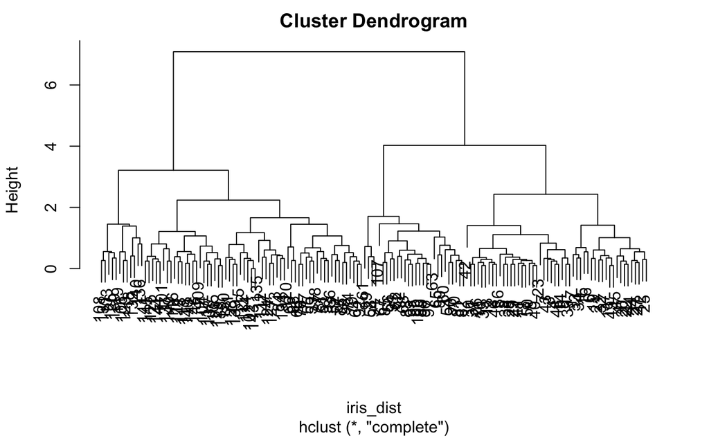

```r
iris_dist <- dist(iris_data)
clusters <- hclust(iris_dist)
plot(clusters)
```

4b. Looking at the display, the optimal clustering threshold I see is 2 clusters, since the height of the 2 clusters is greatest (between 7 and 4). This is interesting because the actual number of clusters is 3, but 2 of those 3 are super close together and easily mistaken for each other. The height for 3 clusters is a super small gap between 3.5 and 4, which doesn’t seem very optimal at all.

4c. The `kmeans` algorithm picked up on the fact that there are 3 clusters, but the `hclust` algorithm shows that there are only 2. The composition of the 3 clusters shows that 1 is separate, and the other 2 are very close together. `hclust` doesn’t distinguish between those 2 close clusters.

### Question 5: dbscan

5a,b. Run dbscan for selected eps and report the cluster size and F-score.

```r
iris_matrix <- as.matrix(iris_data)
for (eps in c(0.2, 0.3, 0.4, 0.5, 0.6, 0.8, 1.0)) {
  clusters <- dbscan::dbscan(iris_matrix, eps)
  metrics <- get_external_metrics(clusters$cluster, target)

  cat("eps value:", eps)
  cat("\nCluster sizes:", as.data.frame(table(clusters$cluster))[,2])
  print_metrics(metrics)
  cat("\n\n")
}
```

```
eps value: 0.2
Cluster sizes: 133 10 7
Precision: 0.3497029
Recall: 0.8317333
F-score: 0.492383

eps value: 0.3
Cluster sizes: 96 37 12 5
Precision: 0.4820532
Recall: 0.6912
F-score: 0.5679851

eps value: 0.4
Cluster sizes: 32 46 36 14 22
Precision: 0.8702111
Recall: 0.5936
F-score: 0.7057705

eps value: 0.5
Cluster sizes: 17 49 84
Precision: 0.62323
Recall: 0.8098667
F-score: 0.7043952

eps value: 0.6
Cluster sizes: 9 49 92
Precision: 0.6089896
Recall: 0.8888
F-score: 0.7227583

eps value: 0.8
Cluster sizes: 2 50 98
Precision: 0.6035679
Recall: 0.9744
F-score: 0.74541

eps value: 1
Cluster sizes: 50 100
Precision: 0.6
Recall: 1
F-score: 0.75
```

5c. The value of `eps` that produces the highest F-score is `1.0`, with an F-score of `0.75`.

5d. This is an interesting result, since this value of `eps` actually only recognizes 2 clusters instead of the 3 that are actually present. Other `eps` values experimented with different numbers of clusters, and a few had 3 clusters but not a high enough F-score. A recall value of `1` means that there were no false negatives identified with `eps=1`, which is interesting and a bit worrying to me.

### Question 6: swiss

```r
swiss_data <- subset(datasets::swiss, select=c(1,2,3,4))
clusters <- kmeans(swiss_data, 2, nstart = 5)
protestant = names(which(clusters$cluster == 1))
catholic = names(which(clusters$cluster == 2))
```

A list of the Swiss cities that are predominantly Protestant:

```r
protestant
```

```
 [1] "Courtelary"   "Grandson"     "Lausanne"     "La Vallee"    "Vevey"        "Boudry"       "La Chauxdfnd" "Le Locle"     "Neuchatel"    "ValdeTravers"
[11] "V. De Geneve" "Rive Droite"  "Rive Gauche"
```

A list of the Swiss cities that are predominantly Catholic:

```r
catholic
```

```
 [1] "Delemont"     "Franches-Mnt" "Moutier"      "Neuveville"   "Porrentruy"   "Broye"        "Glane"        "Gruyere"      "Sarine"       "Veveyse"
[11] "Aigle"        "Aubonne"      "Avenches"     "Cossonay"     "Echallens"    "Lavaux"       "Morges"       "Moudon"       "Nyone"        "Orbe"
[21] "Oron"         "Payerne"      "Paysd'enhaut" "Rolle"        "Yverdon"      "Conthey"      "Entremont"    "Herens"       "Martigwy"     "Monthey"
[31] "St Maurice"   "Sierre"       "Sion"         "Val de Ruz"
```